# Assignment 2

Briana Flynn

9/16/2020

# Instructions

For each continuous variable in your dataset, calculate the sample mean, the sample standard deviation, the 95-percent confidence interval for the population mean, and the interquartile range. Create a histogram to illustrate the distribution of each variable and describe the distribution in a sentence or two.

For each categorical variable in your dataset, calculate the 95-percent confidence interval for the proportion of the population in each category.

# Variables (from Assignment 1)

The distributions and proportions in this assignment are based on the following variables for renter households in Suffolk County, MA.

1. Household income (continuous) : HINCP
2. Gross monthly rent payment (continuous) : GRNTP
3. Gross rent as a percentage of monthly income (continous) : GRPIP
4. Access to the internet (categorical) : ACCESS
5. Limited English speaking household (categorical) : LNGI
6. Presence and age of children in household (categorical): HUPAC

Note: I have excluded year moved “MV” from my list of variables because I decided it is not relevant to the trends I hope to examine.

```r
households <- read_csv("households.csv")
attach(households)
```

# Distribution of Continuous Variables

## Descriptive Statistics

```r
hinc_summary <-  summary(HINCP)
hinc_sd <- sd(HINCP, na.rm = TRUE)
hinc_pop_mean_int <- t.test(HINCP)
grntp_summary <- summary(GRNTP)
grntp_sd <- sd(GRNTP, na.rm = TRUE)
grntp_pop_mean_int <- t.test(GRNTP)
grpip_summary <- summary(GRPIP)
grpip_sd <- sd(GRPIP, na.rm = TRUE)
grpip_pop_mean_int <- t.test(GRPIP)
```

```r
summary_table <- tibble(
  Statistic = c("Sample mean",
                "Median",
                "Standard deviation",
                "Interquartile range",
                "Population mean (95% confidence)"),
  `Household Income (dollars)` = c(prettyNum(hinc_summary["Mean"], digits=3),
                           hinc_summary["Median"],
                           prettyNum(hinc_sd, digits = 3),
                           paste(hinc_summary["1st Qu."],"to",
                                 hinc_summary["3rd Qu."]),
                           paste(prettyNum(hinc_pop_mean_int$conf.int[1],
                                           digits=3), "to",
                                 prettyNum(hinc_pop_mean_int$conf.int[2],
                                               digits=3))),
  `Rent Payment (dollars)` = c(paste(prettyNum(grntp_summary["Mean"],
                                           digits=3)),
                           paste(prettyNum(grntp_summary["Median"],
                                           digits=3)),
                           paste(prettyNum(grntp_sd, digits=3)),
                           paste(prettyNum(grntp_summary["1st Qu."],
                                           digits=3), "to",
                                 prettyNum(grntp_summary["3rd Qu."],
                                           digits=3)),
                           paste(prettyNum(grntp_pop_mean_int$conf.int[1],
                                           digits=3), "to",
                                 prettyNum(grntp_pop_mean_int$conf.int[2],
                                           digits=3))),
  `Rent as a Percentage of Household Income` =
    c(paste(prettyNum(grpip_summary["Mean"], digits=3),"%"),
      paste(prettyNum(grpip_summary["Median"], digits=3),"%"),
      paste(prettyNum(grpip_sd, digits=3),"%"),
      paste(prettyNum(grpip_summary["1st Qu."], digits=3), "% to",
            prettyNum(grpip_summary["3rd Qu."], digits=3), "%"),
      paste(prettyNum(grpip_pop_mean_int$conf.int[1], digits=3), "% to",
            prettyNum(grpip_pop_mean_int$conf.int[2], digits=3), "%")))
knitr::kable(summary_table,
             caption = "Characteristics of census tracts in Suffolk County")
```

Characteristics of census tracts in Suffolk County

| Statistic | Household Income (dollars) | Rent Payment (dollars) | Rent as a Percentage of Household Income |
| --- | --- | --- | --- |
| Sample mean | 83043 | 1541 | 30 % |
| Median | 65000 | 1420 | 25 % |
| Standard deviation | 77683 | 829 | 19.2 % |
| Interquartile range | 33900 to 109000 | 967 to 2020 | 17 % to 38 % |
| Population mean (95% confidence) | 81858 to 84229 | 1528 to 1553 | 29.7 % to 30.3 % |

## Histograms

### Household Income

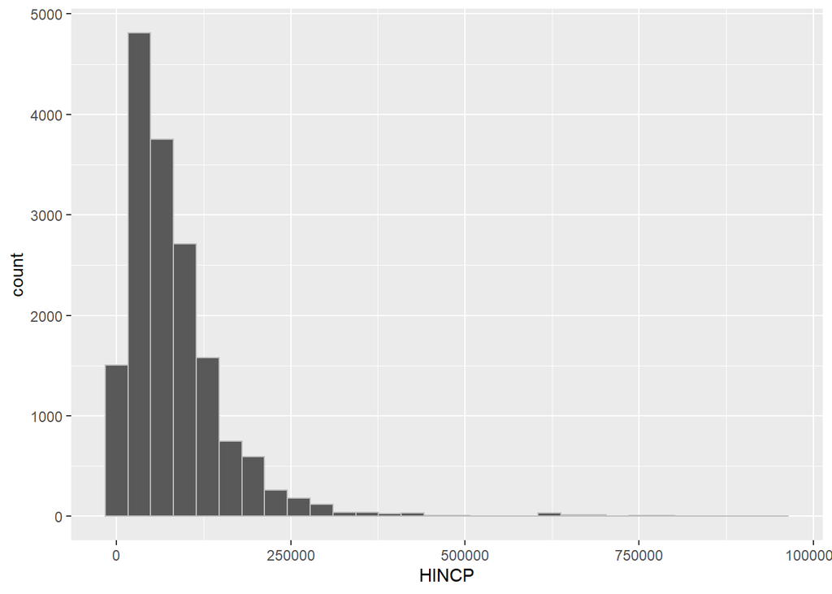

```r
hist <- ggplot(households, aes(x = HINCP))+
  geom_histogram(color = "grey")
hist
```

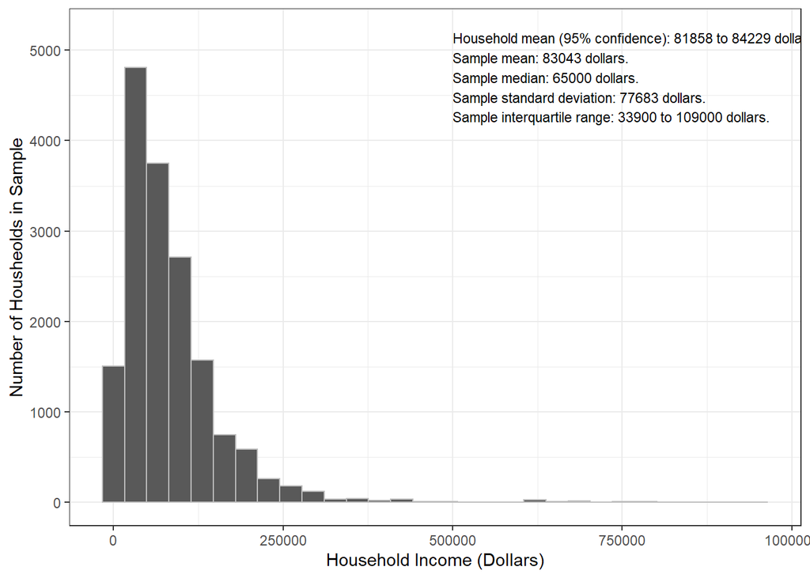

```r
hist +
  theme_bw() +
  scale_x_continuous(name = "Household Income (Dollars)") +
  scale_y_continuous(name = "Number of Housheolds in Sample") +
  annotate("text", x = 500000, y = 5200, size = 3,
           label = paste("Household mean (95% confidence):",
                         prettyNum(hinc_pop_mean_int$conf.int[1], digits = 5),
                         "to",
                         prettyNum(hinc_pop_mean_int$conf.int[2], digits = 5),
                         "dollars.",
                         "\nSample mean:",
                         prettyNum(mean(HINCP), digits = 5), "dollars.",
                         "\nSample median:",
                         prettyNum(median(HINCP), digits = 5), "dollars.",
                         "\nSample standard deviation:",
                         prettyNum(sd(HINCP), digits = 5), "dollars.",
                         "\nSample interquartile range:",
                         prettyNum(quantile(HINCP)["25%"], digits = 5),
                         "to",
                         prettyNum(quantile(HINCP)["75%"], digits = 5),
                         "dollars."),
           hjust = 0, vjust = 1)
```

The distribution of household income is most likely a right-skewed normal distribution. The median value is less than the mean value, because a household cannot technically have a negative income to bring the sample mean down, but one can have a very high household income (here it is apparent that there is a portion of households earning more than $250,000) to bring the mean up.

### Monthly Rent Payment

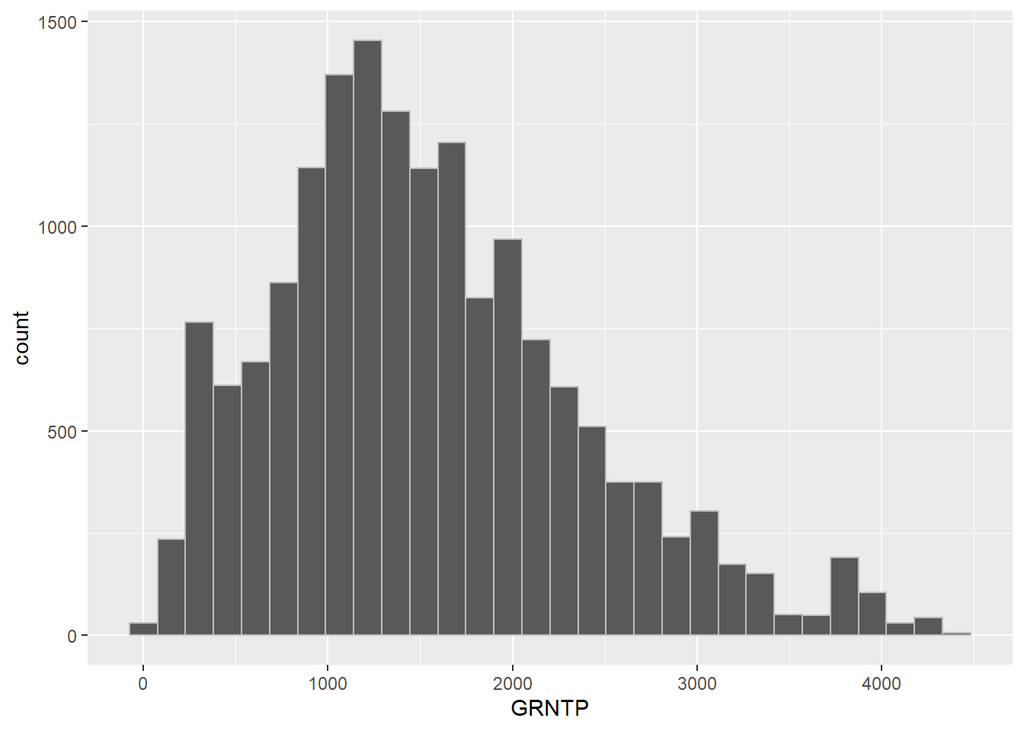

```r
renthist <- ggplot(households, aes(x = GRNTP)) +
  geom_histogram(color = "gray")
renthist
```

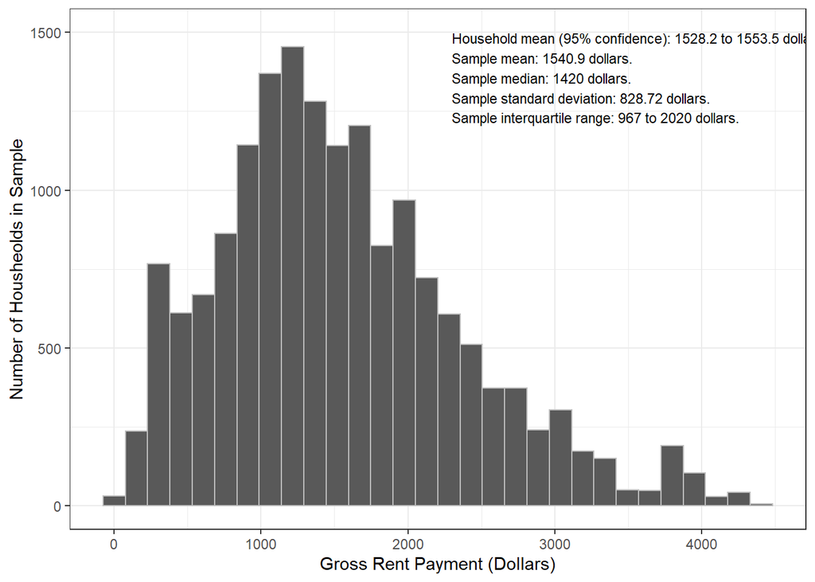

```r
renthist +
  theme_bw() +
  scale_x_continuous(name = "Gross Rent Payment (Dollars)") +
  scale_y_continuous(name = "Number of Housheolds in Sample") +
  annotate("text", x = 2300, y = 1500, size = 3,
           label = paste("Household mean (95% confidence):",
                         prettyNum(grntp_pop_mean_int$conf.int[1], digits = 5),
                         "to",
                         prettyNum(grntp_pop_mean_int$conf.int[2], digits = 5),
                         "dollars.",
                         "\nSample mean:",
                         prettyNum(mean(GRNTP), digits = 5), "dollars.",
                         "\nSample median:",
                         prettyNum(median(GRNTP), digits = 5), "dollars.",
                         "\nSample standard deviation:",
                         prettyNum(sd(GRNTP), digits = 5), "dollars.",
                         "\nSample interquartile range:",
                         prettyNum(quantile(GRNTP)["25%"], digits = 5),
                         "to",
                         prettyNum(quantile(GRNTP)["75%"], digits = 5),
                         "dollars."),
           hjust = 0, vjust = 1)
```

The distribution of monthly rent payment is right skewed, though more normally distributed than household income. Outliers on the higher end cause the mean to be higher than the median. A monthly rent of $2,020 is the 75th percentile rent for Suffolk County in 2018.

### Rent as a Percentage of Monthly Household Income

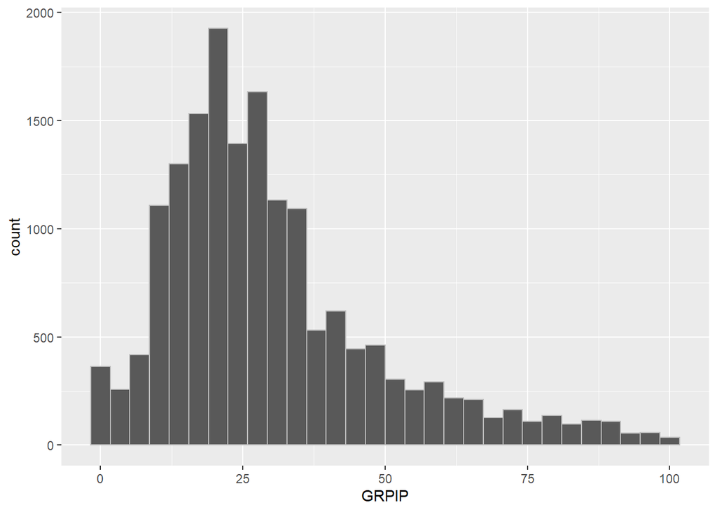

```r
rentburdenhist <- ggplot(households, aes(x = GRPIP)) +
  geom_histogram(color = "grey")
rentburdenhist
```

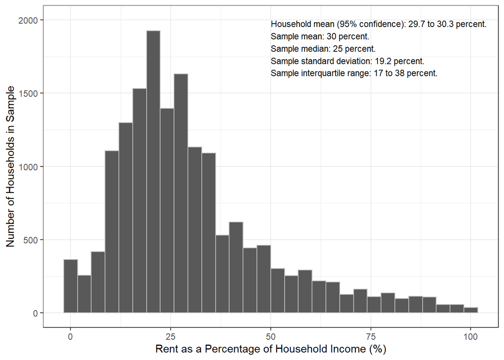

```r
rentburdenhist +
  theme_bw() +
  scale_x_continuous(name = "Rent as a Percentage of Household Income (%)") +
  scale_y_continuous(name = "Number of Households in Sample") +
  annotate("text", x = 50, y = 2000, size = 3,
           label = paste("Household mean (95% confidence):",
                         prettyNum(grpip_pop_mean_int$conf.int[1], digits = 3),
                         "to",
                         prettyNum(grpip_pop_mean_int$conf.int[2], digits = 3),
                         "percent.",
                         "\nSample mean:",
                         prettyNum(mean(GRPIP), digits = 3), "percent.",
                         "\nSample median:",
                         prettyNum(median(GRPIP), digits = 3), "percent.",
                         "\nSample standard deviation:",
                         prettyNum(sd(GRPIP), digits = 3), "percent.",
                         "\nSample interquartile range:",
                         prettyNum(quantile(GRPIP)["25%"], digits = 3),
                         "to",
                         prettyNum(quantile(GRPIP)["75%"], digits = 3),
                         "percent."),
           hjust = 0, vjust = 1)
```

The distribution of monthly rent as a percentage of household income is right skewed. While the median household spends 25% of household income on rent, a quarter of households spend more than 38% of their income on rent and a quarter spent less than 17% of their income on rent.

# Distribution of Categorical Variables

## Presence of Children in Household

```r
children <- unique(households$HUPAC_label)
children
```

```
## [1] "No children"
## [2] "With children 6 to 17 years only"
## [3] "With children under 6 years and 6 to 17 years"
## [4] "With children under 6 years only"
```

```r
None <- t.test(HUPAC_label == children[1])
School_aged <- t.test(HUPAC_label == children[2])
Preschool_and_school_aged <- t.test(HUPAC_label == children[3])
Preschool_aged <- t.test(HUPAC_label == children[4])
shares_children <- tibble(`children` = c("No children",
                            "Children in K-12",
                            "Children in Pre-K and K-12",
                            "Children in Pre-K"),
                 `Share` = c(None$estimate,
                             School_aged$estimate,
                             Preschool_and_school_aged$estimate,
                             Preschool_aged$estimate),
                 `Low` = c(None$conf.int[1],
                         School_aged$conf.int[1],
                         Preschool_and_school_aged$conf.int[1],
                         Preschool_aged$conf.int[1]),
                 `High` = c(None$conf.int[2],
                            School_aged$conf.int[2],
                            Preschool_and_school_aged$conf.int[2],
                            Preschool_aged$conf.int[2]))
```

```r
show(shares_children)
```

```
## # A tibble: 4 x 4
##   children                    Share    Low   High
##   <chr>                       <dbl>  <dbl>  <dbl>
## 1 No children                0.601  0.593  0.608
## 2 Children in K-12           0.204  0.198  0.210
## 3 Children in Pre-K and K-12 0.0946 0.0902 0.0991
## 4 Children in Pre-K          0.101  0.0962 0.105
```

```r
shares_children_format <- tibble(`HUPAC_label` = c("No children","Children in K-12", "Children in Pre-K and K-12", "Children in Pre-K"),
                     `Sample proportion` =
                       c(paste(prettyNum(None$estimate*100,
                                         digits = 3), "%"),
                         paste(prettyNum(School_aged$estimate*100,
                                         digits = 3), "%"),
                         paste(prettyNum(Preschool_and_school_aged$estimate*100,
                                         digits = 3), "%"),
                         paste(prettyNum(Preschool_aged$estimate*100,
                                         digits = 3), "%")),
                      `95-percent confidence interval` =
                        c(paste(prettyNum(None$conf.int[1]*100,
                                          digits = 3), "% to ",
                                prettyNum(None$conf.int[2]*100,
                                          digits = 3), "%"),
                         paste(prettyNum(School_aged$conf.int[1]*100,
                                          digits = 3), "% to ",
                                prettyNum(School_aged$conf.int[2]*100,
                                          digits = 3), "%"),
                         paste(prettyNum(Preschool_and_school_aged$conf.int[1]*100,
                                          digits = 3), "% to ",
                                prettyNum(Preschool_and_school_aged$conf.int[2]*100,
                                          digits = 3), "%"),
                         paste(prettyNum(Preschool_aged$conf.int[1]*100,
                                          digits = 3), "% to ",
                                prettyNum(Preschool_aged$conf.int[2]*100,
                                          digits = 3), "%")))
knitr::kable(shares_children_format, caption = "Census tracts in Suffolk County")
```

Census tracts in Suffolk County

| HUPAC_label | Sample proportion | 95-percent confidence interval |
| --- | --- | --- |
| No children | 60.1 % | 59.3 % to 60.8 % |
| Children in K-12 | 20.4 % | 19.8 % to 21 % |
| Children in Pre-K and K-12 | 9.46 % | 9.02 % to 9.91 % |
| Children in Pre-K | 10.1 % | 9.62 % to 10.5 % |

## Internet Access in Household

```r
access <- unique(ACCESS_label)
access
```

```
## [1] "Yes, by paying a cell phone company or Internet service provider"
## [2] "Yes, without paying a cell phone company or Internet service provider"
## [3] "No access to the Internet at this house, apartment, or mobile home"
```

```r
Yes_pay <- t.test(ACCESS_label == access[1])
Yes_dontpay <- t.test(ACCESS_label == access[2])
No <- t.test(ACCESS_label == access[3])
shares_access <- tibble(`access` = c("YP",
                            "Y",
                            "N"),
                 `Share` = c(Yes_pay$estimate,
                             Yes_dontpay$estimate,
                             No$estimate),
                 `Low` = c(Yes_pay$conf.int[1],
                         Yes_dontpay$conf.int[1],
                         No$conf.int[1]),
                 `High` = c(Yes_pay$conf.int[2],
                            Yes_dontpay$conf.int[2],
                            No$conf.int[2]))
```

```r
show(shares_access)
```

```
## # A tibble: 3 x 4
##   access  Share    Low   High
##   <chr>   <dbl>  <dbl>  <dbl>
## 1 YP     0.885  0.881  0.890
## 2 Y      0.0248 0.0224 0.0272
## 3 N      0.0898 0.0854 0.0941
```

```r
shares_access_format <- tibble(`ACCESS_label` = c("Yes, paid for","Yes, not paid for", "No access"),
                     `Sample proportion` =
                       c(paste(prettyNum(Yes_pay$estimate*100,
                                         digits = 3), "%"),
                         paste(prettyNum(Yes_dontpay$estimate*100,
                                         digits = 3), "%"),
                         paste(prettyNum(No$estimate*100,
                                         digits = 3), "%")),
                      `95-percent confidence interval` =
                        c(paste(prettyNum(Yes_pay$conf.int[1]*100,
                                          digits = 3), "% to ",
                                prettyNum(Yes_pay$conf.int[2]*100,
                                          digits = 3), "%"),
                         paste(prettyNum(Yes_dontpay$conf.int[1]*100,
                                          digits = 3), "% to ",
                                prettyNum(Yes_dontpay$conf.int[2]*100,
                                          digits = 3), "%"),
                         paste(prettyNum(No$conf.int[1]*100,
                                          digits = 3), "% to ",
                                prettyNum(No$conf.int[2]*100,
                                          digits = 3), "%")))
knitr::kable(shares_access_format, caption = "Census tracts in Suffolk County")
```

Census tracts in Suffolk County

| ACCESS_label | Sample proportion | 95-percent confidence interval |
| --- | --- | --- |
| Yes, paid for | 88.5 % | 88.1 % to 89 % |
| Yes, not paid for | 2.48 % | 2.24 % to 2.72 % |
| No access | 8.98 % | 8.54 % to 9.41 % |

## English-speaking Ability in Households

```r
LNGI <- unique(LNGI_label)
LNGI
```

```
## [1] "At least one person in the household 14 and over speaks English only or speaks English 'very well'"
## [2] "No one in the household 14 and over speaks English only or speaks English 'very well'"
```

```r
English <- t.test(LNGI_label == LNGI[1])
NoEnglish <- t.test(LNGI_label == LNGI[2])
shares_LNGI <- tibble(`LNGI` = c("English proficient",
                            "Not English proficient"),
                 `Share` = c(English$estimate,
                             NoEnglish$estimate),
                 `Low` = c(English$conf.int[1],
                         NoEnglish$conf.int[1]),
                 `High` = c(English$conf.int[2],
                            NoEnglish$conf.int[2]))
```

```r
show(shares_LNGI)
```

```
## # A tibble: 2 x 4
##   LNGI                    Share    Low  High
##   <chr>                   <dbl>  <dbl> <dbl>
## 1 English proficient     0.901  0.896  0.905
## 2 Not English proficient 0.0994 0.0948 0.104
```

```r
shares_LNGI_format <- tibble(`LNGI` = c("English proficient","Not English proficient"),
                     `Sample proportion` =
                       c(paste(prettyNum(English$estimate*100,
                                         digits = 3), "%"),
                         paste(prettyNum(NoEnglish$estimate*100,
                                         digits = 3), "%")),
                      `95-percent confidence interval` =
                        c(paste(prettyNum(English$conf.int[1]*100,
                                          digits = 3), "% to ",
                                prettyNum(English$conf.int[2]*100,
                                          digits = 3), "%"),
                         paste(prettyNum(NoEnglish$conf.int[1]*100,
                                          digits = 3), "% to ",
                                prettyNum(NoEnglish$conf.int[2]*100,
                                          digits = 3), "%")))
knitr::kable(shares_LNGI_format, caption = "Census tracts in Suffolk County")
```

Census tracts in Suffolk County

| LNGI | Sample proportion | 95-percent confidence interval |
| --- | --- | --- |
| English proficient | 90.1 % | 89.6 % to 90.5 % |
| Not English proficient | 9.94 % | 9.48 % to 10.4 % |